# Differential signaling interaction analysis across multiple datasets

## Visualize the results

We provide function `plotNebulaVolcano()` to visualize all interactions affected by a single variable on a volcano plot. Here we separately make the volcano plots for diffusion-dependent and contact-dependent interactions. This function also features interactive browser mode, powered by Plotly, when setting `interactive = TRUE`.

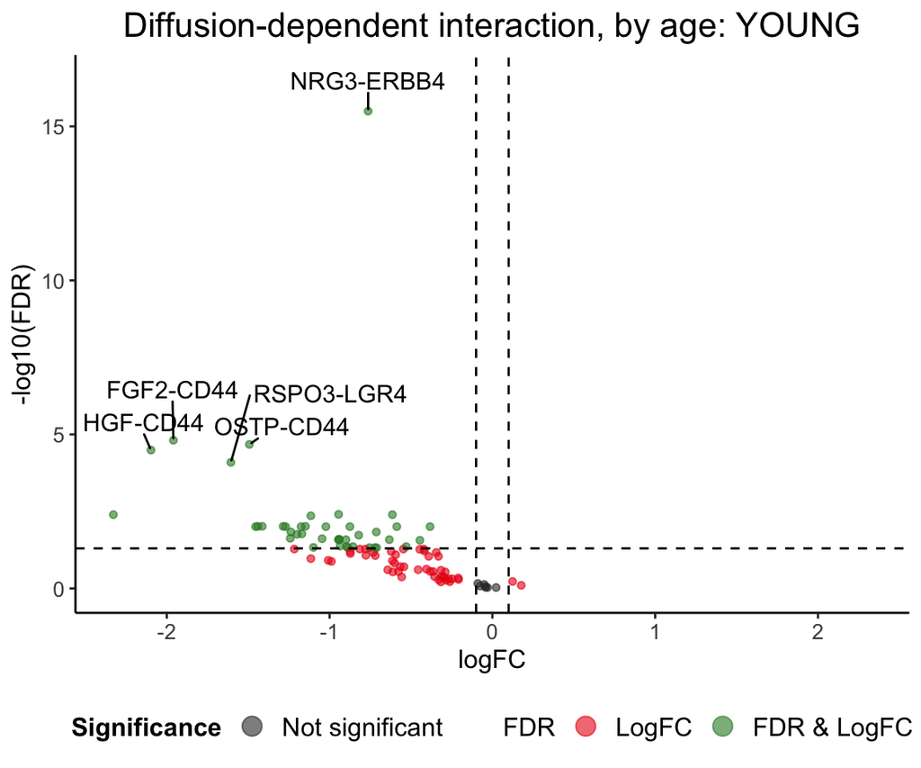

```r
plotNebulaVolcano(
  multics, covariate = 'age_YOUNG', intr.type = 'diff',
  fdrThresh = 0.05, logfcThresh = 0.1, interactive = FALSE
)
```

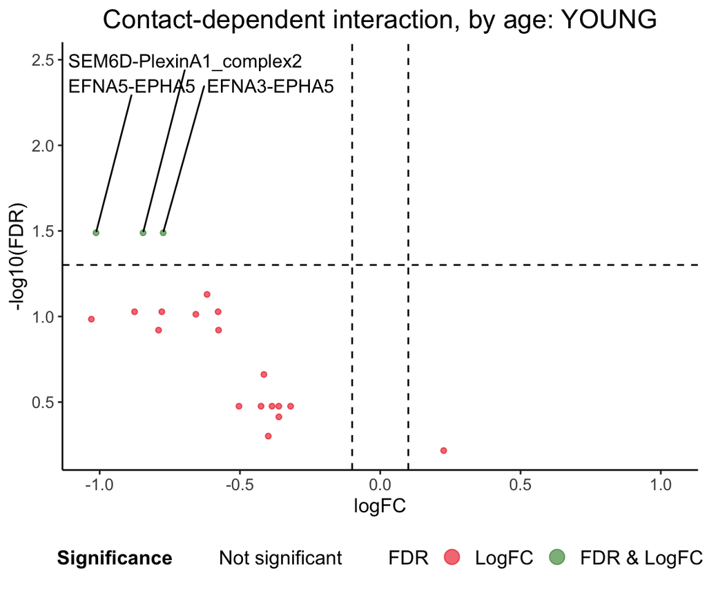

```r
plotNebulaVolcano(
  multics, covariate = 'age_YOUNG', intr.type = 'cont',
  fdrThresh = 0.05, logfcThresh = 0.1, interactive = FALSE
)
```

Positive logFC values indicate up-regulated signaling within the class specified by the variable. In the example above, interaction ‘OSTP-CD44’, a.k.a. Spp1-Cd44 signaling in mouse, is tested with negative logFC value and high -log10(padj). This indicates its significant up-regulation in non-YOUNG group, which is “OLD”. This observation of increased signaling activity in the old mice is consistent with the finding reported in the original study.

Furthermore, we also provide a faceted bubble plot to show the result of all variables. This can be helpful for quickly identifying the variable that has the most differentially signaling interactions.

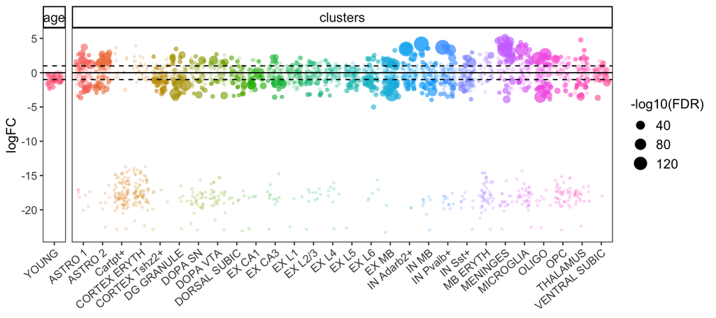

```r
plotNebulaAll(multics, intr.type = 'diff')
```

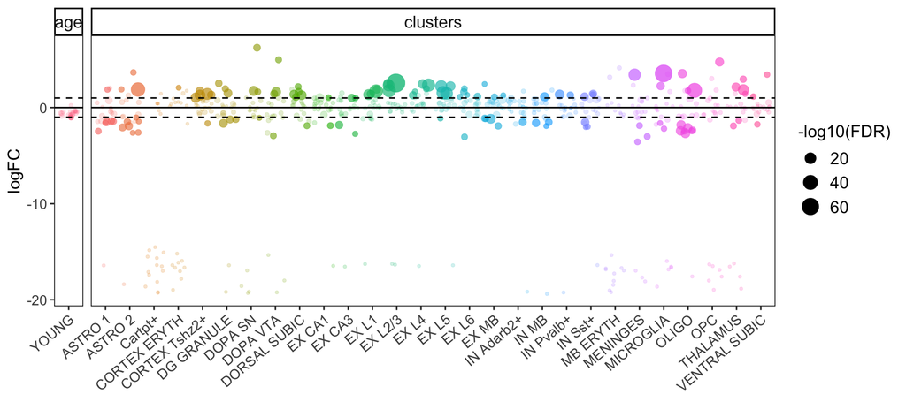

```r
plotNebulaAll(multics, intr.type = 'cont')
```